# R Presentations for the CERN Study Group

Achintya Rao

17 February 2017

# Some eye-candy

## Responsive presentations with interactivity

- Example repo: github.com/RaoOfPhysics/201604_PCST
- In action: via.hypothes.is/https://raoofphysics.github.io/201604_PCST/
- File generating the presentation: raw.githubusercontent.com/RaoOfPhysics/201604_PCST/gh-pages/index.Rmd
- Zenodo DOI: 10.5281/zenodo.50791

# HOWTO

## Tool chain

- [R](https://www.r-project.org/) + [RStudio](https://www.rstudio.com/)
- [R Markdown](http://rmarkdown.rstudio.com/) [[Cheatsheet PDF](https://www.rstudio.com/wp-content/uploads/2015/02/rmarkdown-cheatsheet.pdf)] – authoring
- [ggplot2](http://ggplot2.org/) – making plots
- [plotly](https://plot.ly/) – plot interactivity
- [reveal.js](http://lab.hakim.se/reveal-js/) – displaying
- [GitHub Pages](https://pages.github.com/) – sharing
- [Hypothesis](https://hypothes.is/) – annotating

## Workflow

- Create a directory for your project
- Open RStudio
- Create a new `R Markdown` HTML file named `index.Rmd`
- Switch to console run:
  - `install.packages("ggplot2")`
  - `install.packages("plotly")`
  - `install.packages("revealjs")`

## Workflow (contd.)

- Add [YAML](http://www.yaml.org/) frontmatter!
- Instructions for reveal.js presentations: rmarkdown.rstudio.com/revealjs_presentation_format.html
- Create sections and add content
- Knit your presentation!

# Using R code in your presentation

- Source: https://jofrhwld.github.io/avml2012/

## Example of some code

```r
summary(mtcars)
```

```
##       mpg             cyl             disp             hp
##  Min.   :10.40   Min.   :4.000   Min.   : 71.1   Min.   : 52.0
##  1st Qu.:15.43   1st Qu.:4.000   1st Qu.:120.8   1st Qu.: 96.5
##  Median :19.20   Median :6.000   Median :196.3   Median :123.0
##  Mean   :20.09   Mean   :6.188   Mean   :230.7   Mean   :146.7
##  3rd Qu.:22.80   3rd Qu.:8.000   3rd Qu.:326.0   3rd Qu.:180.0
##  Max.   :33.90   Max.   :8.000   Max.   :472.0   Max.   :335.0
##       drat             wt             qsec             vs
##  Min.   :2.760   Min.   :1.513   Min.   :14.50   Min.   :0.0000
##  1st Qu.:3.080   1st Qu.:2.581   1st Qu.:16.89   1st Qu.:0.0000
##  Median :3.695   Median :3.325   Median :17.71   Median :0.0000
##  Mean   :3.597   Mean   :3.217   Mean   :17.85   Mean   :0.4375
##  3rd Qu.:3.920   3rd Qu.:3.610   3rd Qu.:18.90   3rd Qu.:1.0000
##  Max.   :4.930   Max.   :5.424   Max.   :22.90   Max.   :1.0000
##        am              gear            carb
##  Min.   :0.0000   Min.   :3.000   Min.   :1.000
##  1st Qu.:0.0000   1st Qu.:3.000   1st Qu.:2.000
##  Median :0.0000   Median :4.000   Median :2.000
##  Mean   :0.4062   Mean   :3.688   Mean   :2.812
##  3rd Qu.:1.0000   3rd Qu.:4.000   3rd Qu.:4.000
##  Max.   :1.0000   Max.   :5.000   Max.   :8.000
```

## Static plots

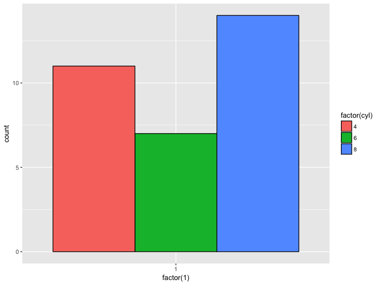

## Interactive plots!

[interactive chart not shown]

## Import some data

```r
I_jean <- read.delim("http://bit.ly/avml_ggplot2_data")
head(I_jean)
```

```
##    Name Age Sex Word FolSegTrans Dur_msec     F1     F2      F1.n
## 1 Jean   61   f  I'M           M      130  861.7 1335.8 1.6608625
## 2 Jean   61   f    I           N      140 1010.4 1349.3 2.6882695
## 3 Jean   61   f I'LL           L      110  670.1 1292.7 0.3370482
## 4 Jean   61   f  I'M           M      180  869.8 1307.0 1.7168275
## 5 Jean   61   f    I           R       80  743.0 1418.7 0.8407333
## 6 Jean   61   f I'VE           V      120  918.2 1580.8 2.0512357
##         F2.n
## 1 -0.8855366
## 2 -0.8536494
## 3 -0.9873394
## 4 -0.9535626
## 5 -0.6897257
## 6 -0.3068434
```

## Make more plots!

[interactive chart not shown]

# Versioning, sharing, archiving

## Git going!

- `$ git init`
- Create a `.gitignore` and include `.RData` and `.Rhistory`
- Add `index.Rmd` and `index.html`
- Commit!

## Hosting your presentation on GitHub

- Create a GitHub repository to store your code and presentation
- Push to GitHub
- Activate GitHub Pages
- **Important!** Don’t forget to include `README` and `LICENSE` files!
- This presentation: github.com/RaoOfPhysics/201702_R-presentations
- Point to the presentation website in your repo’s description…
- … with the [*via* proxy](https://hypothes.is/blog/meetvia/) from hypothesis for annotations

## Commit early, commit often

- Preparing your presentation is an opportunity for collaboration
- Send all your commits to GitHub and deploy your presentation incrementally
- Receive feedback in the form of issues or pull requests

## Archiving on Zenodo

- [Zenodo](https://zenodo.org/) is a service provided by CERN for archiving all kinds of research outputs, including presentations
- After giving your talk (with the final file), create a “Release” and send it off to Zenodo
  - guides.github.com/activities/citable-code/
  - zenodo.org/account/settings/github/
- Mint a DOI and add a badge to your `README`

## Questions?

Discussion here: [github:CERNStudyGroup/cernstudygroup.github.io #46](https://github.com/CERNStudyGroup/cernstudygroup.github.io/issues/46)